# R-Based Forecasting of Türkiye’s Monthly Export Volume Index Using TÜİK Data

Emrecan Karaçay

2026-05-28

# 1. Project Overview

This project forecasts Türkiye’s monthly Export Volume Index using data obtained from the TÜİK Data Portal. The selected series is the general export volume index from the Monthly Volume Indices by Standard International Trade Classification table.

The purpose of the project is to apply alternative quantitative forecasting methods, compare their forecast accuracy, select the most suitable method, and forecast the next available monthly period.

# 2. Data Source and TÜİK Connection

The selected data set was obtained from the TÜİK Data Portal. The relevant TÜİK table was identified in R using the `tuikr` package. Since direct access through `statistical_data()` returned an authorization error, the table URL obtained from `tuikr::statistical_tables()` was accessed programmatically in R using `httr::GET()`.

No manually downloaded, manually edited, copy-pasted, or externally prepared data file was used.

**TÜİK data set name:** Monthly Volume Indices by Standard International Trade Classification  
**TÜİK theme/category:** International Trade  
**TÜİK table name:** Monthly Volume Indices by Standart International Trade Classification  
**Selected variable:** Export Volume Index — General  
**Data frequency:** Monthly  
**Base year:** 2015=100

# 3. Package Setup

```r
library(tuikr)
library(tidyverse)
library(lubridate)
library(forecast)
library(zoo)
library(httr)
library(readxl)
library(rvest)
library(janitor)
library(ggplot2)
library(scales)

dir.create("outputs", showWarnings = FALSE)
dir.create("outputs/tables", recursive = TRUE, showWarnings = FALSE)
dir.create("outputs/figures", recursive = TRUE, showWarnings = FALSE)
```

# 4. Data Access Process

```r
# Access TÜİK International Trade tables
tables <- statistical_tables("17")

# Select monthly volume indices tables
volume_istab_tables <- tables %>%
  filter(
    node_type == "istab",
    grepl("Monthly Volume Indices", table_name, ignore.case = TRUE)
  )

volume_istab_tables %>%
  select(table_name, node_type, dataflow_id, table_url)
```

```
## # A tibble: 2 × 4
##   table_name                                     node_type dataflow_id table_url
##   <chr>                                          <chr>     <chr>       <chr>
## 1 Monthly Volume Indices by Standart Internatio… istab     <NA>        https://…
## 2 Monthly Volume Indices by Standart Internatio… istab     <NA>        https://…
```

```r
# Select the first matching table URL
selected_url_1 <- volume_istab_tables$table_url[1]

# Retrieve TÜİK data programmatically in R
response_1 <- httr::GET(
  selected_url_1,
  httr::add_headers(
    "User-Agent" = "Mozilla/5.0 (Macintosh; Intel Mac OS X 10_15_7) AppleWebKit/537.36 Chrome/120.0 Safari/537.36",
    "Accept" = "application/vnd.openxmlformats-officedocument.spreadsheetml.sheet,application/vnd.ms-excel,application/octet-stream,text/html,application/json,text/plain,*/*",
    "Accept-Language" = "en-US,en;q=0.9,tr;q=0.8",
    "Referer" = "https://veriportali.tuik.gov.tr/",
    "Origin" = "https://veriportali.tuik.gov.tr",
    "Connection" = "keep-alive"
  )
)

# Check connection status
httr::status_code(response_1)
```

```
## [1] 200
```

```r
# Read the Excel content returned by TÜİK
temp_file_1 <- tempfile(fileext = ".xls")
writeBin(httr::content(response_1, "raw"), temp_file_1)

raw_data_1 <- readxl::read_excel(temp_file_1)

head(raw_data_1)
```

```
## # A tibble: 6 × 15
##   Uluslararası Standart …¹  ...2 ...3  ...4  ...5  ...6  ...7  ...8  ...9  ...10
##   <chr>                    <dbl> <chr> <chr> <chr> <chr> <chr> <chr> <lgl> <chr>
## 1 Monthly volume indices …    NA <NA>  <NA>  <NA>  <NA>  <NA>   <NA> NA    <NA>
## 2 [2015=100, SITC Rev.4]      NA <NA>  <NA>  <NA>  <NA>  <NA>   <NA> NA    <NA>
## 3 <NA>                        NA İhra… <NA>  <NA>  <NA>  <NA>   <NA> NA    İtha…
## 4 <NA>                        NA Gene… Gıda… Ham … Yakı… İmal… "SIT… NA    Gene…
## 5 2013                         1 83.2… 96.2… 108.… 115.… 79.8… "56.… NA    87.7…
## 6 <NA>                         2 88.9… 87.1… 107.… 114.… 87.9… "65.… NA    89.6…
## # ℹ abbreviated name:
## #   ¹`Uluslararası Standart Ticaret Sınıflamasına göre aylık dış ticaret miktar endeksleri`
## # ℹ 5 more variables: ...11 <chr>, ...12 <chr>, ...13 <chr>, ...14 <chr>,
## #   ...15 <chr>
```

# 5. Data Preparation

The raw TÜİK table contains title rows and hierarchical column labels. The selected series is the general export volume index under the “İhracat-Exports” category. The year column is filled downward because the original TÜİK table reports the year once and leaves the following monthly rows blank.

```r
export_general <- raw_data_1 %>%
  slice(5:n()) %>%
  select(
    year = 1,
    month = 2,
    export_volume_index = 3
  ) %>%
  fill(year, .direction = "down") %>%
  filter(!is.na(month), !is.na(export_volume_index)) %>%
  mutate(
    year = as.integer(year),
    month = as.integer(month),
    export_volume_index = as.numeric(export_volume_index),
    date = as.Date(paste(year, month, "01", sep = "-"))
  ) %>%
  arrange(date)

head(export_general, 12)
```

```
## # A tibble: 12 × 4
##     year month export_volume_index date
##    <int> <int>               <dbl> <date>
##  1  2013     1                83.3 2013-01-01
##  2  2013     2                89.0 2013-02-01
##  3  2013     3                97.0 2013-03-01
##  4  2013     4                93.6 2013-04-01
##  5  2013     5                98.5 2013-05-01
##  6  2013     6                90.3 2013-06-01
##  7  2013     7                97.0 2013-07-01
##  8  2013     8                82.8 2013-08-01
##  9  2013     9                97.1 2013-09-01
## 10  2013    10                90.2 2013-10-01
## 11  2013    11               106.  2013-11-01
## 12  2013    12                96.3 2013-12-01
```

```r
tail(export_general, 12)
```

```
## # A tibble: 12 × 4
##     year month export_volume_index date
##    <int> <int>               <dbl> <date>
##  1  2025     4                140. 2025-04-01
##  2  2025     5                165. 2025-05-01
##  3  2025     6                135. 2025-06-01
##  4  2025     7                157. 2025-07-01
##  5  2025     8                138. 2025-08-01
##  6  2025     9                142. 2025-09-01
##  7  2025    10                151. 2025-10-01
##  8  2025    11                141. 2025-11-01
##  9  2025    12                166. 2025-12-01
## 10  2026     1                125. 2026-01-01
## 11  2026     2                129. 2026-02-01
## 12  2026     3                133. 2026-03-01
```

# 6. Time Coverage and Forecast Target Period

```r
first_period <- min(export_general$date)
latest_period <- max(export_general$date)

forecast_target_period <- seq(latest_period, by = "month", length.out = 2)[2]

time_coverage <- paste0(format(first_period, "%Y-%m"), " / ", format(latest_period, "%Y-%m"))
latest_available_observation <- format(latest_period, "%Y-%m")
forecast_target <- format(forecast_target_period, "%Y-%m")

time_coverage
```

```
## [1] "2013-01 / 2026-03"
```

```r
latest_available_observation
```

```
## [1] "2026-03"
```

```r
forecast_target
```

```
## [1] "2026-04"
```

```r
nrow(export_general)
```

```
## [1] 159
```

The selected time series covers the period from **2013-01 to 2026-03** and contains **159 monthly observations**. The latest available TÜİK observation is **2026-03**, so the forecast target period is **2026-04**.

# 7. Data Quality Checks

```r
# Check missing monthly periods
expected_dates <- seq(
  from = min(export_general$date),
  to = max(export_general$date),
  by = "month"
)

missing_dates <- setdiff(expected_dates, export_general$date)

length(missing_dates)
```

```
## [1] 0
```

```r
missing_dates
```

```
## Date of length 0
```

```r
# Check duplicate periods
export_general %>%
  count(date) %>%
  filter(n > 1)
```

```
## # A tibble: 0 × 2
## # ℹ 2 variables: date <date>, n <int>
```

```r
# Check missing values in the selected variable
sum(is.na(export_general$export_volume_index))
```

```
## [1] 0
```

The selected series has no missing monthly periods, no duplicate periods, and no missing values in the selected variable. Therefore, it is suitable for time series forecasting.

# 8. Exploratory Time Series Analysis

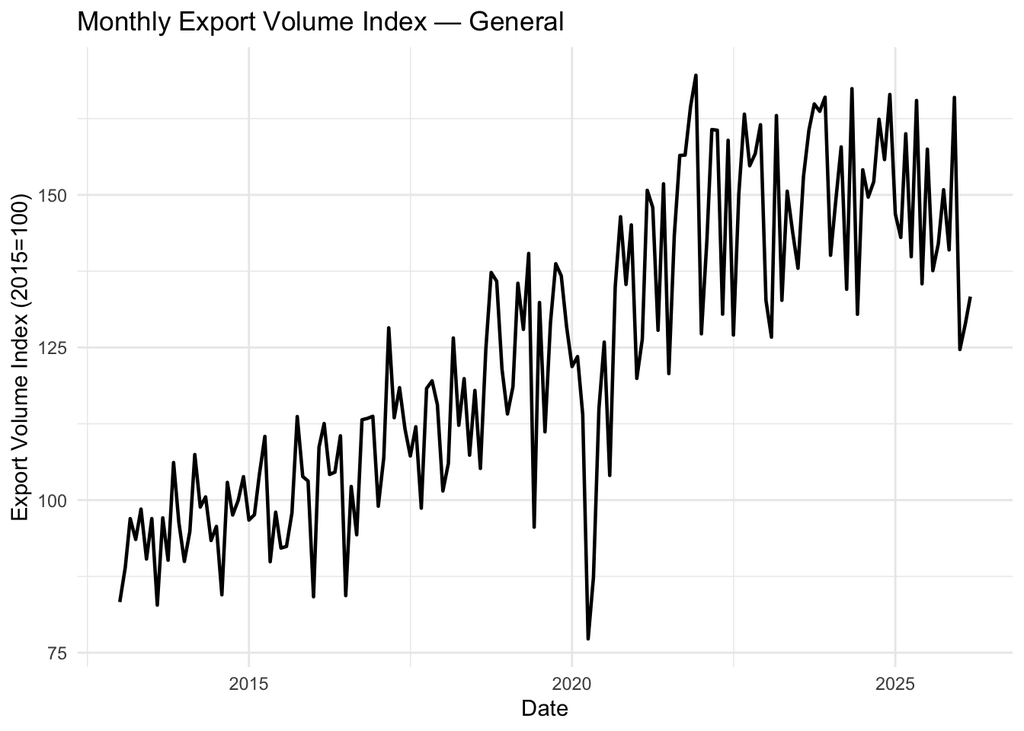

```r
actual_series_plot <- ggplot(export_general, aes(x = date, y = export_volume_index)) +
  geom_line(linewidth = 0.8) +
  labs(
    title = "Monthly Export Volume Index — General",
    x = "Date",
    y = "Export Volume Index (2015=100)"
  ) +
  theme_minimal()

actual_series_plot
```

```r
ggsave(
  filename = "outputs/figures/actual_series_plot.png",
  plot = actual_series_plot,
  width = 10,
  height = 6,
  dpi = 300
)
```

The selected time series represents Türkiye’s monthly general Export Volume Index based on 2015=100. The plot suggests that the export volume index has an upward long-term movement with visible monthly fluctuations. Since the data are monthly and contain repeated observations over time, trend and seasonality should be considered in the forecasting stage.

# 9. Time Series Object

```r
start_year <- export_general$year[1]
start_month <- export_general$month[1]

export_ts <- ts(
  export_general$export_volume_index,
  start = c(start_year, start_month),
  frequency = 12
)

export_ts
```

```
##            Jan       Feb       Mar       Apr       May       Jun       Jul
## 2013  83.29901  88.96671  96.96223  93.55208  98.52302  90.34240  96.96744
## 2014  89.95349  94.85029 107.46076  98.85998 100.52028  93.37776  95.68538
## 2015  96.72726  97.60609 104.19538 110.43287  89.90906  98.01706  92.14184
## 2016  84.16686 108.68420 112.54412 104.19738 104.57675 110.52739  84.34892
## 2017  98.99943 106.94365 128.21604 113.49920 118.42071 111.64107 107.22931
## 2018 101.49397 106.00053 126.55920 112.25618 119.89131 107.36187 117.96123
## 2019 114.11268 118.55896 135.52550 127.96831 140.40438  95.56764 132.37016
## 2020 121.87909 123.50963 114.13668  77.26352  87.33544 114.97940 125.87582
## 2021 119.93620 126.33900 150.74528 147.95019 127.82130 151.80939 120.72939
## 2022 127.23950 142.47155 160.70108 160.59552 130.46252 158.93640 127.04094
## 2023 132.70047 126.69149 162.99358 132.72660 150.60382 143.84405 137.97843
## 2024 140.10431 149.50741 157.85598 134.53778 167.39873 130.43615 154.11166
## 2025 146.87581 143.02994 160.01313 139.87349 165.46308 135.43568 157.48672
## 2026 124.67614 128.90809 133.33672
##            Aug       Sep       Oct       Nov       Dec
## 2013  82.80319  97.08798  90.15292 106.15080  96.31744
## 2014  84.48418 102.89733  97.55650  99.92454 103.83955
## 2015  92.40353  97.89086 113.68626 103.85619 103.13361
## 2016 102.22605  94.31839 113.16194 113.38644 113.72772
## 2017 112.00747  98.68274 118.29067 119.53091 115.62670
## 2018 105.18401 124.78462 137.28322 135.85806 121.48206
## 2019 111.18562 129.02184 138.71986 136.74682 128.44396
## 2020 104.04052 134.93519 146.42077 135.32697 145.07714
## 2021 143.39231 156.46314 156.51812 164.50310 169.59678
## 2022 150.34285 163.22417 154.77365 156.72344 161.49150
## 2023 152.98949 160.64316 164.89956 163.69135 166.00189
## 2024 149.63425 152.14841 162.38743 155.78494 166.44947
## 2025 137.59027 141.99138 150.83924 140.98571 165.96928
## 2026
```

# 10. Forecast Accuracy Functions

The following helper functions are used to calculate the required forecast accuracy and monitoring measures for each candidate forecasting method.

```r
calculate_accuracy <- function(actual, forecast, method_name, next_forecast) {
  valid_index <- !is.na(actual) & !is.na(forecast)

  actual_valid <- actual[valid_index]
  forecast_valid <- forecast[valid_index]

  errors <- actual_valid - forecast_valid

  bias <- mean(errors)
  mad <- mean(abs(errors))
  mse <- mean(errors^2)
  mape <- mean(abs(errors / actual_valid)) * 100
  rsfe <- sum(errors)
  tracking_signal <- ifelse(mad == 0, NA, rsfe / mad)

  tibble(
    Method = method_name,
    Bias = bias,
    MAD = mad,
    MSE = mse,
    MAPE = mape,
    RSFE = rsfe,
    Tracking_Signal = tracking_signal,
    Next_Period_Forecast = as.numeric(next_forecast)
  )
}

plot_actual_vs_forecast <- function(data, forecast_column, title, file_name) {
  plot_data <- data %>%
    select(date, actual = export_volume_index, forecast = all_of(forecast_column)) %>%
    pivot_longer(
      cols = c(actual, forecast),
      names_to = "Series",
      values_to = "Value"
    )

  p <- ggplot(plot_data, aes(x = date, y = Value, linetype = Series)) +
    geom_line(linewidth = 0.8, na.rm = TRUE) +
    labs(
      title = title,
      x = "Date",
      y = "Export Volume Index (2015=100)",
      linetype = "Series"
    ) +
    theme_minimal()

  print(p)

  ggsave(
    filename = paste0("outputs/figures/", file_name),
    plot = p,
    width = 10,
    height = 6,
    dpi = 300
  )
}
```

# 11. Naïve Forecasting

Naïve forecasting assumes that the forecast for the next period is equal to the most recent actual observation. This method is simple and useful as a baseline forecasting method.

```r
naive_data <- export_general %>%
  mutate(
    naive_forecast = lag(export_volume_index)
  )

naive_next_forecast <- tail(export_general$export_volume_index, 1)

naive_accuracy <- calculate_accuracy(
  actual = naive_data$export_volume_index,
  forecast = naive_data$naive_forecast,
  method_name = "Naïve Forecasting",
  next_forecast = naive_next_forecast
)

naive_accuracy
```

```
## # A tibble: 1 × 8
##   Method       Bias   MAD   MSE  MAPE  RSFE Tracking_Signal Next_Period_Forecast
##   <chr>       <dbl> <dbl> <dbl> <dbl> <dbl>           <dbl>                <dbl>
## 1 Naïve Fore… 0.317  13.0  271.  10.7  50.0            3.84                 133.
```

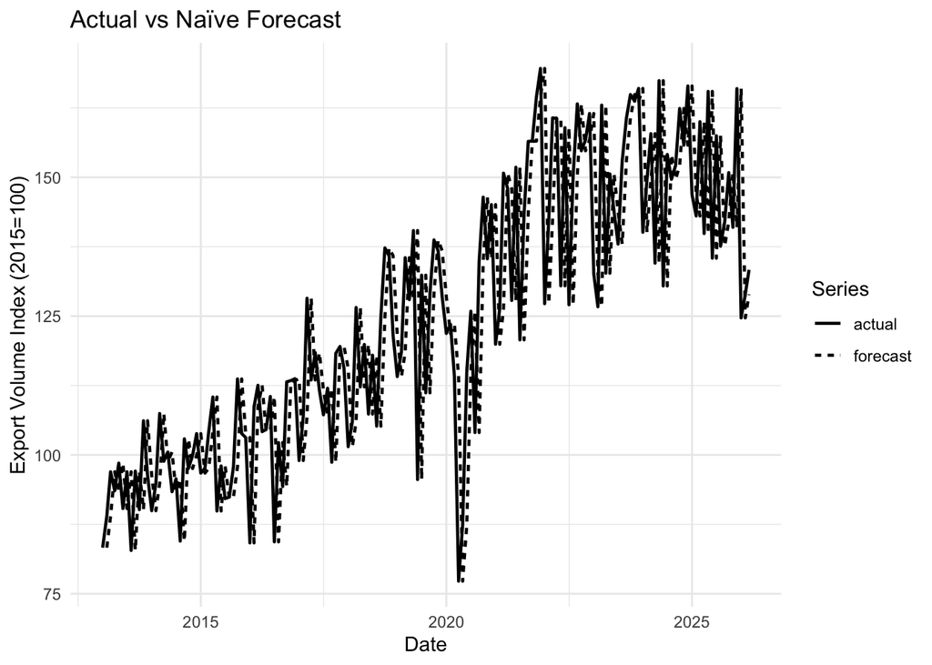

```r
plot_actual_vs_forecast(
  data = naive_data,
  forecast_column = "naive_forecast",
  title = "Actual vs Naïve Forecast",
  file_name = "naive_forecast_plot.png"
)
```

The naïve forecasting method uses the previous month’s export volume index as the forecast for the current month. It provides a simple benchmark model. However, because it does not explicitly model trend or seasonality, it may perform poorly when the series has systematic monthly fluctuations or long-term movement.

# 12. Moving Average

A moving average forecast smooths short-term fluctuations by averaging the most recent observations. In this project, a 3-month moving average is used because the data are monthly and this window captures short-term movements without excessive smoothing.

```r
ma_window <- 3

moving_average_data <- export_general %>%
  mutate(
    moving_average_forecast = zoo::rollmean(
      export_volume_index,
      k = ma_window,
      align = "right",
      fill = NA
    )
  ) %>%
  mutate(
    moving_average_forecast = lag(moving_average_forecast)
  )

moving_average_next_forecast <- mean(
  tail(export_general$export_volume_index, ma_window),
  na.rm = TRUE
)

moving_average_accuracy <- calculate_accuracy(
  actual = moving_average_data$export_volume_index,
  forecast = moving_average_data$moving_average_forecast,
  method_name = "Moving Average",
  next_forecast = moving_average_next_forecast
)

moving_average_accuracy
```

```
## # A tibble: 1 × 8
##   Method       Bias   MAD   MSE  MAPE  RSFE Tracking_Signal Next_Period_Forecast
##   <chr>       <dbl> <dbl> <dbl> <dbl> <dbl>           <dbl>                <dbl>
## 1 Moving Ave… 0.492  11.2  191.  9.21  76.8            6.83                 129.
```

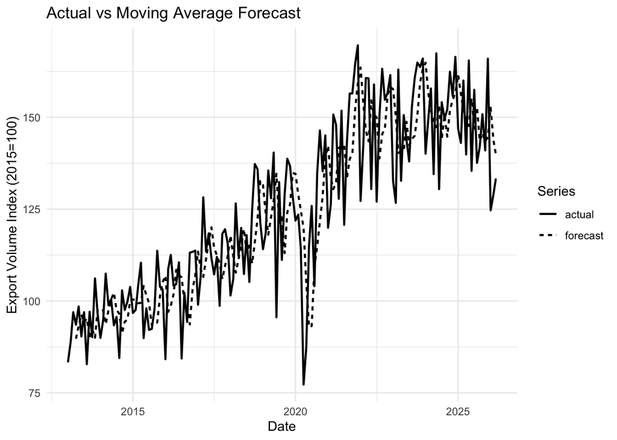

```r
plot_actual_vs_forecast(
  data = moving_average_data,
  forecast_column = "moving_average_forecast",
  title = "Actual vs Moving Average Forecast",
  file_name = "moving_average_plot.png"
)
```

The 3-month moving average reduces short-term volatility by averaging the most recent three monthly observations. This method is useful for smoothing random variation, but it may lag behind the actual series when there is a strong trend or seasonal movement.

# 13. Weighted Moving Average

Weighted moving average gives different importance to recent observations. In this project, more weight is assigned to recent months because recent export movements are expected to be more informative for the next period.

```r
weights <- c(0.2, 0.3, 0.5)

weighted_ma_values <- rep(NA, nrow(export_general))

for (i in 4:nrow(export_general)) {
  previous_values <- export_general$export_volume_index[(i - 3):(i - 1)]
  weighted_ma_values[i] <- sum(previous_values * weights)
}

weighted_ma_data <- export_general %>%
  mutate(
    weighted_moving_average_forecast = weighted_ma_values
  )

weighted_ma_next_forecast <- sum(
  tail(export_general$export_volume_index, 3) * weights
)

weighted_ma_accuracy <- calculate_accuracy(
  actual = weighted_ma_data$export_volume_index,
  forecast = weighted_ma_data$weighted_moving_average_forecast,
  method_name = "Weighted Moving Average",
  next_forecast = weighted_ma_next_forecast
)

weighted_ma_accuracy
```

```
## # A tibble: 1 × 8
##   Method       Bias   MAD   MSE  MAPE  RSFE Tracking_Signal Next_Period_Forecast
##   <chr>       <dbl> <dbl> <dbl> <dbl> <dbl>           <dbl>                <dbl>
## 1 Weighted M… 0.414  11.0  193.  9.02  64.6            5.85                 130.
```

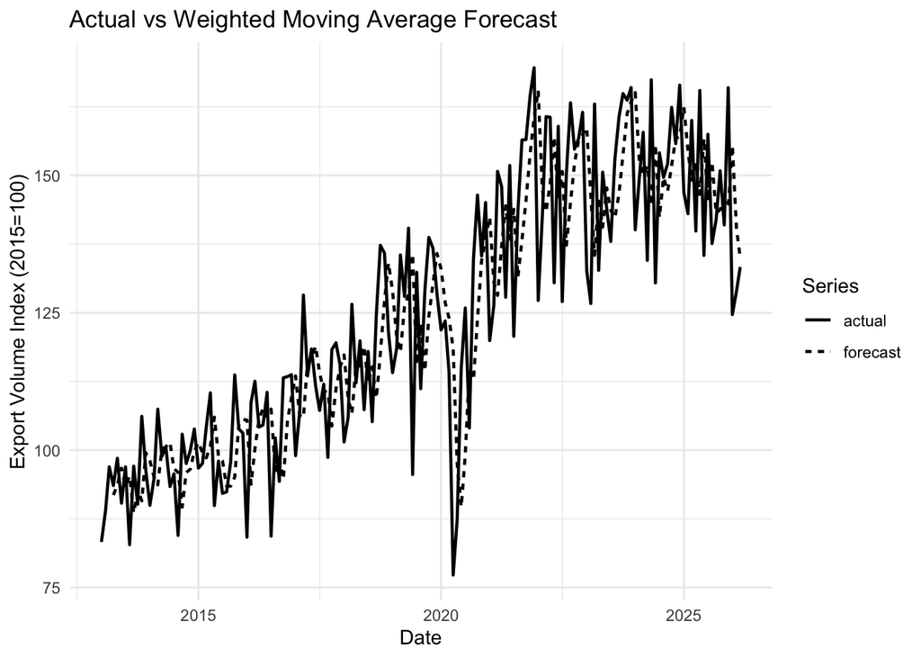

```r
plot_actual_vs_forecast(
  data = weighted_ma_data,
  forecast_column = "weighted_moving_average_forecast",
  title = "Actual vs Weighted Moving Average Forecast",
  file_name = "weighted_moving_average_plot.png"
)
```

The selected weights are 0.2, 0.3, and 0.5, with the highest weight given to the most recent month. This weighting logic is reasonable because recent export volume movements may better reflect current trade conditions.

# 14. Exponential Smoothing

Simple exponential smoothing gives more importance to recent observations while still using the full historical series. It is suitable as a baseline smoothing method, especially when the series does not require an explicit trend or seasonal structure.

```r
ses_model <- forecast::ses(export_ts, h = 1)

ses_fitted <- as.numeric(fitted(ses_model))

exponential_smoothing_data <- export_general %>%
  mutate(
    exponential_smoothing_forecast = ses_fitted
  )

exponential_smoothing_next_forecast <- as.numeric(ses_model$mean[1])

exponential_smoothing_accuracy <- calculate_accuracy(
  actual = exponential_smoothing_data$export_volume_index,
  forecast = exponential_smoothing_data$exponential_smoothing_forecast,
  method_name = "Exponential Smoothing",
  next_forecast = exponential_smoothing_next_forecast
)

ses_model
```

```
##          Point Forecast    Lo 80    Hi 80    Lo 95    Hi 95
## Apr 2026       140.0109 123.3345 156.6873 114.5066 165.5152
```

```r
exponential_smoothing_accuracy
```

```
## # A tibble: 1 × 8
##   Method       Bias   MAD   MSE  MAPE  RSFE Tracking_Signal Next_Period_Forecast
##   <chr>       <dbl> <dbl> <dbl> <dbl> <dbl>           <dbl>                <dbl>
## 1 Exponentia…  1.46  10.4  167.  8.48  232.            22.2                 140.
```

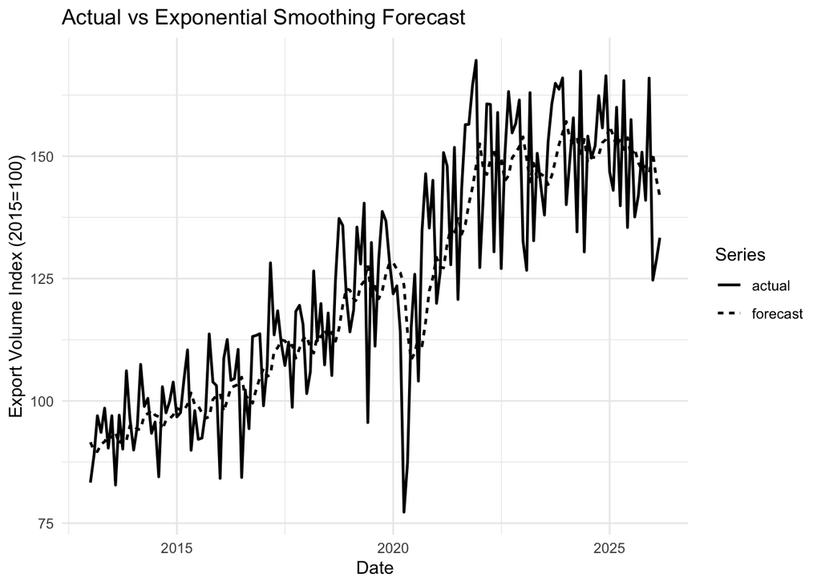

```r
plot_actual_vs_forecast(
  data = exponential_smoothing_data,
  forecast_column = "exponential_smoothing_forecast",
  title = "Actual vs Exponential Smoothing Forecast",
  file_name = "exponential_smoothing_plot.png"
)
```

The exponential smoothing method automatically estimates the smoothing parameter. This method is useful for smoothing the series, but it may not fully capture trend and seasonality if these components are important in the export volume index.

# 15. Trend-Adjusted Exponential Smoothing

Trend-adjusted exponential smoothing is used when a time series shows a meaningful trend. Since the export volume index shows a long-term upward movement, a Holt trend method is applied.

```r
holt_model <- forecast::holt(export_ts, h = 1)

holt_fitted <- as.numeric(fitted(holt_model))

trend_adjusted_data <- export_general %>%
  mutate(
    trend_adjusted_forecast = holt_fitted
  )

trend_adjusted_next_forecast <- as.numeric(holt_model$mean[1])

trend_adjusted_accuracy <- calculate_accuracy(
  actual = trend_adjusted_data$export_volume_index,
  forecast = trend_adjusted_data$trend_adjusted_forecast,
  method_name = "Trend-Adjusted Exponential Smoothing",
  next_forecast = trend_adjusted_next_forecast
)

holt_model
```

```
##          Point Forecast    Lo 80    Hi 80    Lo 95    Hi 95
## Apr 2026       143.5107 126.8623 160.1591 118.0492 168.9722
```

```r
trend_adjusted_accuracy
```

```
## # A tibble: 1 × 8
##   Method       Bias   MAD   MSE  MAPE  RSFE Tracking_Signal Next_Period_Forecast
##   <chr>       <dbl> <dbl> <dbl> <dbl> <dbl>           <dbl>                <dbl>
## 1 Trend-Ad… -0.0255  10.1  165.  8.31 -4.05          -0.400                 144.
```

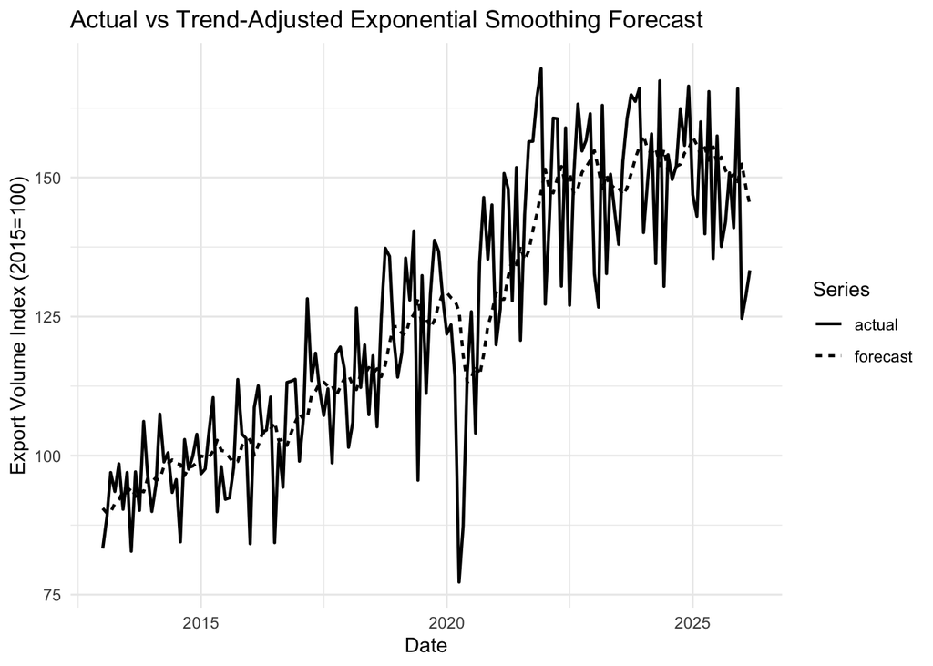

```r
plot_actual_vs_forecast(
  data = trend_adjusted_data,
  forecast_column = "trend_adjusted_forecast",
  title = "Actual vs Trend-Adjusted Exponential Smoothing Forecast",
  file_name = "trend_adjusted_smoothing_plot.png"
)
```

Trend-adjusted exponential smoothing is appropriate because the series shows a visible long-term movement. This method extends simple exponential smoothing by adding a trend component, so it can react better to upward or downward movement in the series.

# 16. Linear Trend Projection

Linear trend projection estimates a regression model using time as the explanatory variable. The model captures the average long-term direction of the export volume index.

```r
trend_data <- export_general %>%
  mutate(
    time_index = row_number()
  )

linear_trend_model <- lm(export_volume_index ~ time_index, data = trend_data)

trend_data <- trend_data %>%
  mutate(
    linear_trend_forecast = as.numeric(predict(linear_trend_model, newdata = trend_data))
  )

next_time_index <- max(trend_data$time_index) + 1

linear_trend_next_forecast <- predict(
  linear_trend_model,
  newdata = tibble(time_index = next_time_index)
)

linear_trend_accuracy <- calculate_accuracy(
  actual = trend_data$export_volume_index,
  forecast = trend_data$linear_trend_forecast,
  method_name = "Linear Trend Projection",
  next_forecast = linear_trend_next_forecast
)

summary(linear_trend_model)
```

```
##
## Call:
## lm(formula = export_volume_index ~ time_index, data = trend_data)
##
## Residuals:
##     Min      1Q  Median      3Q     Max
## -50.559  -8.065   0.814   8.507  32.902
##
## Coefficients:
##             Estimate Std. Error t value Pr(>|t|)
## (Intercept) 88.78316    2.12967   41.69   <2e-16 ***
## time_index   0.44362    0.02309   19.21   <2e-16 ***
## ---
## Signif. codes:  0 '***' 0.001 '**' 0.01 '*' 0.05 '.' 0.1 ' ' 1
##
## Residual standard error: 13.36 on 157 degrees of freedom
## Multiple R-squared:  0.7016, Adjusted R-squared:  0.6997
## F-statistic: 369.1 on 1 and 157 DF,  p-value: < 2.2e-16
```

```r
linear_trend_accuracy
```

```
## # A tibble: 1 × 8
##   Method                      Bias   MAD   MSE  MAPE     RSFE Tracking_Signal
##   <chr>                      <dbl> <dbl> <dbl> <dbl>    <dbl>           <dbl>
## 1 Linear Trend Projection 3.39e-14  10.3  176.  8.40 5.23e-12        5.08e-13
## # ℹ 1 more variable: Next_Period_Forecast <dbl>
```

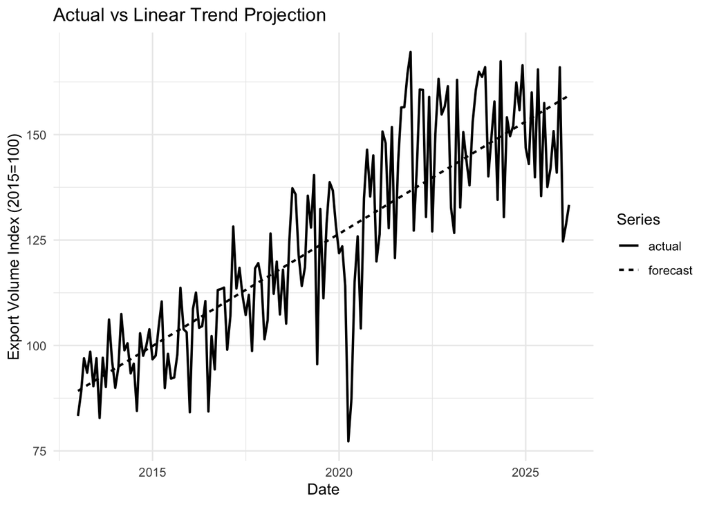

```r
plot_actual_vs_forecast(
  data = trend_data,
  forecast_column = "linear_trend_forecast",
  title = "Actual vs Linear Trend Projection",
  file_name = "trend_projection_plot.png"
)
```

The estimated intercept represents the predicted export volume index at the beginning of the time scale, while the slope represents the average monthly change in the export volume index. A positive slope indicates an upward long-term trend.

# 17. Seasonal Indices

Since the data are monthly, seasonal indices can be calculated to identify recurring monthly patterns. The seasonal index shows whether a particular month tends to be above or below the overall average level.

```r
seasonal_index_table <- export_general %>%
  mutate(month_name = month.abb[month]) %>%
  group_by(month, month_name) %>%
  summarise(
    monthly_average = mean(export_volume_index, na.rm = TRUE),
    .groups = "drop"
  ) %>%
  mutate(
    overall_average = mean(export_general$export_volume_index, na.rm = TRUE),
    seasonal_index = monthly_average / overall_average
  ) %>%
  arrange(month)

seasonal_index_table
```

```
## # A tibble: 12 × 5
##    month month_name monthly_average overall_average seasonal_index
##    <int> <chr>                <dbl>           <dbl>          <dbl>
##  1     1 Jan                   113.            124.          0.909
##  2     2 Feb                   119.            124.          0.955
##  3     3 Mar                   132.            124.          1.06
##  4     4 Apr                   120.            124.          0.962
##  5     5 May                   123.            124.          0.991
##  6     6 Jun                   119.            124.          0.955
##  7     7 Jul                   119.            124.          0.959
##  8     8 Aug                   118.            124.          0.946
##  9     9 Sep                   127.            124.          1.02
## 10    10 Oct                   134.            124.          1.08
## 11    11 Nov                   133.            124.          1.07
## 12    12 Dec                   135.            124.          1.09
```

```r
seasonal_indices_data <- export_general %>%
  left_join(seasonal_index_table %>% select(month, seasonal_index), by = "month") %>%
  mutate(
    deseasonalized_value = export_volume_index / seasonal_index
  )

# Trend model on deseasonalized values
seasonal_trend_data <- seasonal_indices_data %>%
  mutate(time_index = row_number())

seasonal_trend_model <- lm(deseasonalized_value ~ time_index, data = seasonal_trend_data)

seasonal_indices_forecast_data <- seasonal_trend_data %>%
  mutate(
    deseasonalized_forecast = as.numeric(predict(seasonal_trend_model, newdata = seasonal_trend_data)),
    seasonal_indices_forecast = deseasonalized_forecast * seasonal_index
  )

next_month <- as.integer(format(forecast_target_period, "%m"))
next_seasonal_index <- seasonal_index_table %>%
  filter(month == next_month) %>%
  pull(seasonal_index)

next_deseasonalized_forecast <- predict(
  seasonal_trend_model,
  newdata = tibble(time_index = max(seasonal_trend_data$time_index) + 1)
)

seasonal_indices_next_forecast <- as.numeric(next_deseasonalized_forecast * next_seasonal_index)

seasonal_indices_accuracy <- calculate_accuracy(
  actual = seasonal_indices_forecast_data$export_volume_index,
  forecast = seasonal_indices_forecast_data$seasonal_indices_forecast,
  method_name = "Seasonal Indices",
  next_forecast = seasonal_indices_next_forecast
)

seasonal_indices_accuracy
```

```
## # A tibble: 1 × 8
##   Method       Bias   MAD   MSE  MAPE  RSFE Tracking_Signal Next_Period_Forecast
##   <chr>       <dbl> <dbl> <dbl> <dbl> <dbl>           <dbl>                <dbl>
## 1 Seasonal… -0.0440  8.48  130.  7.00 -6.99          -0.825                 153.
```

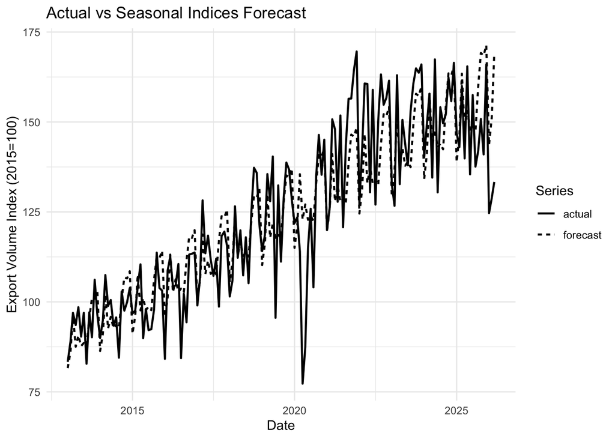

```r
plot_actual_vs_forecast(
  data = seasonal_indices_forecast_data,
  forecast_column = "seasonal_indices_forecast",
  title = "Actual vs Seasonal Indices Forecast",
  file_name = "seasonal_indices_plot.png"
)
```

The seasonal indices show which months are typically above or below the overall average export volume index. This method is useful because the selected data are monthly and may contain recurring seasonal patterns.

# 18. Additive Decomposition

Additive decomposition separates the series into trend, seasonal, and random components. It is suitable when seasonal fluctuations are relatively stable in size over time.

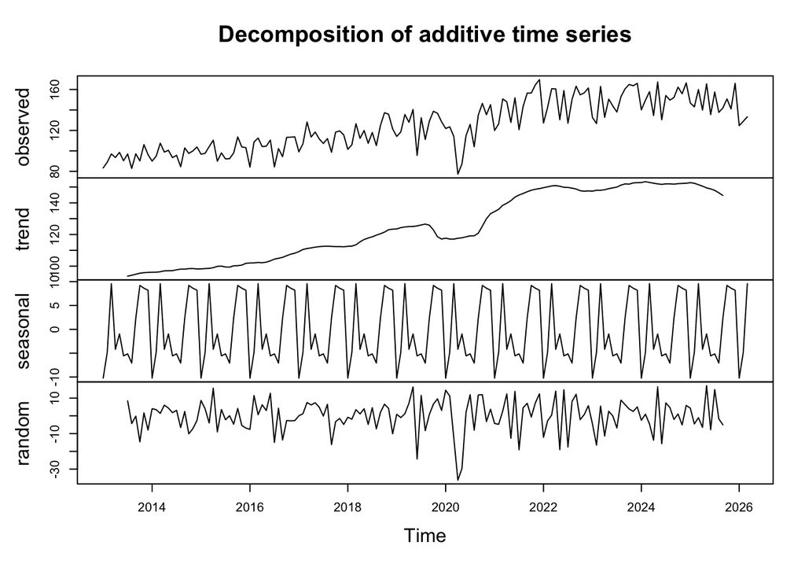

```r
additive_decomp <- decompose(export_ts, type = "additive")

plot(additive_decomp)
```

```r
additive_adjusted <- seasadj(additive_decomp)

additive_trend_model <- tslm(additive_adjusted ~ trend)

additive_forecast_adjusted <- forecast(additive_trend_model, h = 1)

additive_fitted_adjusted <- as.numeric(fitted(additive_trend_model))

additive_seasonal_component <- as.numeric(additive_decomp$seasonal)

additive_fitted_full <- additive_fitted_adjusted + additive_seasonal_component

additive_data <- export_general %>%
  mutate(
    additive_decomposition_forecast = additive_fitted_full
  )

# Seasonal component for the next month
next_month_position <- cycle(ts(rep(NA, length(export_ts) + 1), start = start(export_ts), frequency = 12))[length(export_ts) + 1]
next_additive_seasonal <- tapply(additive_seasonal_component, cycle(export_ts), mean, na.rm = TRUE)[next_month_position]

additive_next_forecast <- as.numeric(additive_forecast_adjusted$mean[1] + next_additive_seasonal)

additive_accuracy <- calculate_accuracy(
  actual = additive_data$export_volume_index,
  forecast = additive_data$additive_decomposition_forecast,
  method_name = "Additive Decomposition",
  next_forecast = additive_next_forecast
)

additive_accuracy
```

```
## # A tibble: 1 × 8
##   Method    Bias   MAD   MSE  MAPE     RSFE Tracking_Signal Next_Period_Forecast
##   <chr>    <dbl> <dbl> <dbl> <dbl>    <dbl>           <dbl>                <dbl>
## 1 Additiv…     0  8.58  132.  7.09 2.84e-14        3.31e-15                 155.
```

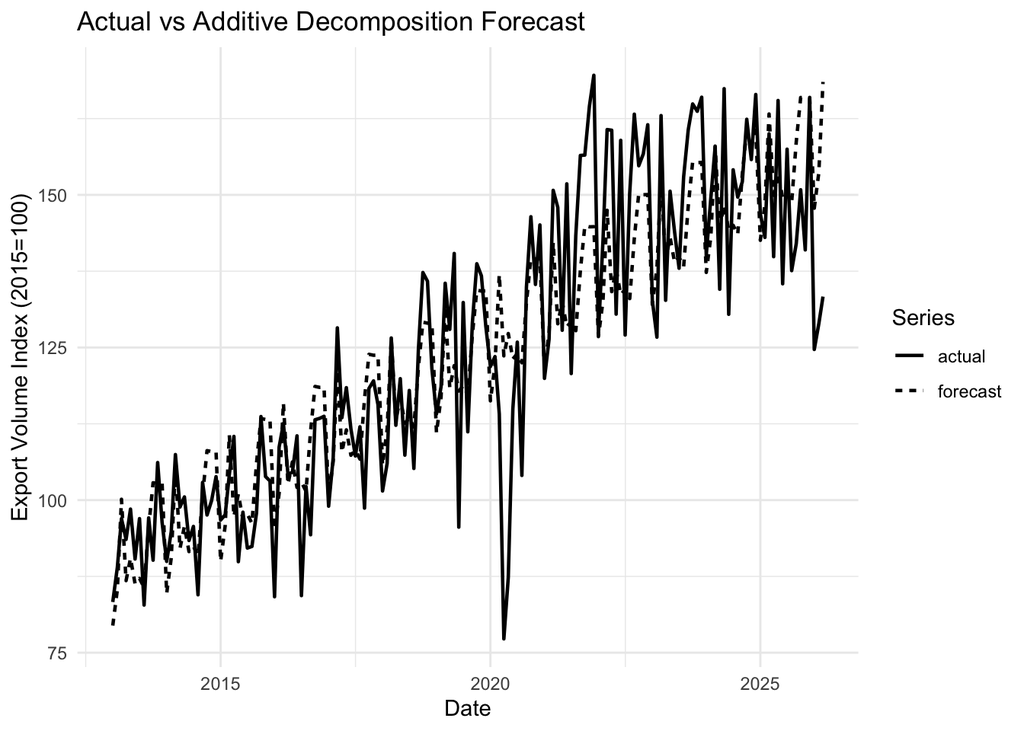

```r
plot_actual_vs_forecast(
  data = additive_data,
  forecast_column = "additive_decomposition_forecast",
  title = "Actual vs Additive Decomposition Forecast",
  file_name = "additive_decomposition_plot.png"
)
```

Additive decomposition separates the export volume index into trend, seasonal, and residual components. This method is useful when the size of seasonal movements is relatively constant over time.

# 19. Multiplicative Decomposition

Multiplicative decomposition separates the series into trend, seasonal, and random components using a multiplicative structure. Since the export volume index values are positive, this method is applicable.

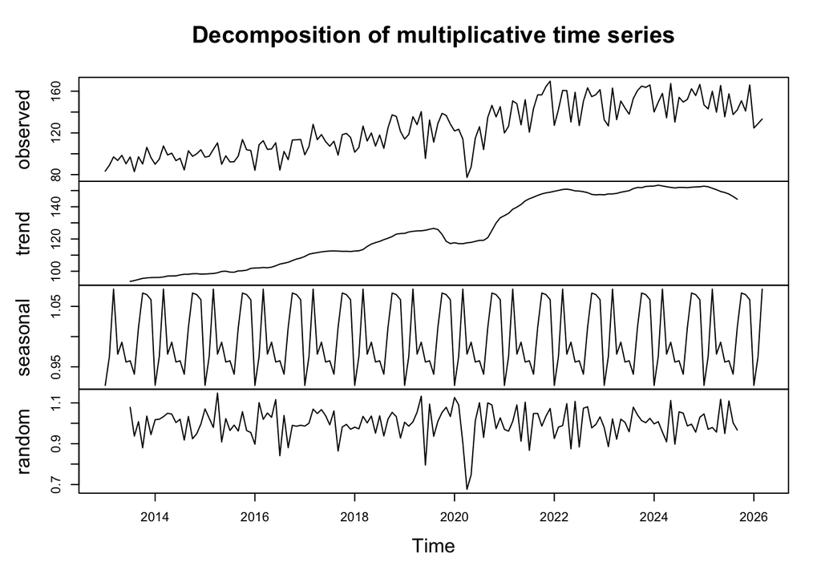

```r
multiplicative_decomp <- decompose(export_ts, type = "multiplicative")

plot(multiplicative_decomp)
```

```r
multiplicative_adjusted <- seasadj(multiplicative_decomp)

multiplicative_trend_model <- tslm(multiplicative_adjusted ~ trend)

multiplicative_forecast_adjusted <- forecast(multiplicative_trend_model, h = 1)

multiplicative_fitted_adjusted <- as.numeric(fitted(multiplicative_trend_model))

multiplicative_seasonal_component <- as.numeric(multiplicative_decomp$seasonal)

multiplicative_fitted_full <- multiplicative_fitted_adjusted * multiplicative_seasonal_component

multiplicative_data <- export_general %>%
  mutate(
    multiplicative_decomposition_forecast = multiplicative_fitted_full
  )

# Seasonal component for the next month
next_month_position <- cycle(ts(rep(NA, length(export_ts) + 1), start = start(export_ts), frequency = 12))[length(export_ts) + 1]
next_multiplicative_seasonal <- tapply(multiplicative_seasonal_component, cycle(export_ts), mean, na.rm = TRUE)[next_month_position]

multiplicative_next_forecast <- as.numeric(multiplicative_forecast_adjusted$mean[1] * next_multiplicative_seasonal)

multiplicative_accuracy <- calculate_accuracy(
  actual = multiplicative_data$export_volume_index,
  forecast = multiplicative_data$multiplicative_decomposition_forecast,
  method_name = "Multiplicative Decomposition",
  next_forecast = multiplicative_next_forecast
)

multiplicative_accuracy
```

```
## # A tibble: 1 × 8
##   Method       Bias   MAD   MSE  MAPE  RSFE Tracking_Signal Next_Period_Forecast
##   <chr>       <dbl> <dbl> <dbl> <dbl> <dbl>           <dbl>                <dbl>
## 1 Multipli… -0.0124  8.39  132.  6.88 -1.96          -0.234                 155.
```

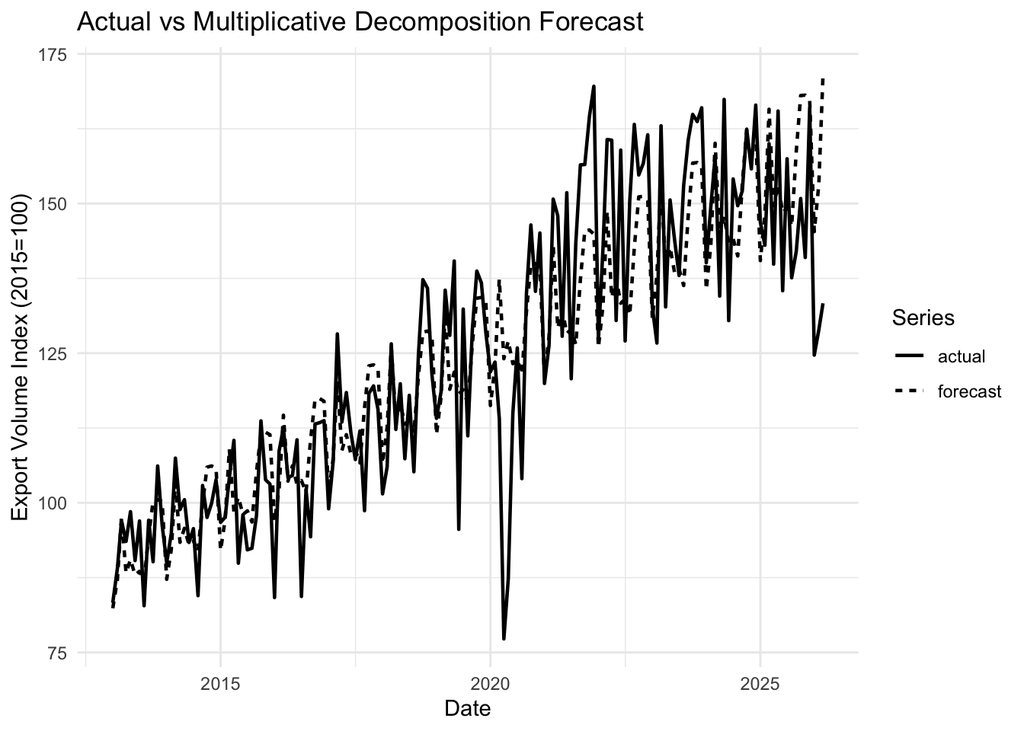

```r
plot_actual_vs_forecast(
  data = multiplicative_data,
  forecast_column = "multiplicative_decomposition_forecast",
  title = "Actual vs Multiplicative Decomposition Forecast",
  file_name = "multiplicative_decomposition_plot.png"
)
```

Multiplicative decomposition is appropriate when seasonal fluctuations change proportionally with the level of the series. Since the export volume index is positive throughout the observed period, this method can be applied.

# 20. Regression with Trend and Seasonal Dummy Variables

This model uses both a time trend and monthly seasonal dummy variables. Since the selected data are monthly, seasonal dummy variables are appropriate.

```r
regression_data <- export_general %>%
  mutate(
    time_index = row_number(),
    month_factor = factor(month)
  )

seasonal_dummy_model <- lm(
  export_volume_index ~ time_index + month_factor,
  data = regression_data
)

regression_data <- regression_data %>%
  mutate(
    regression_seasonal_dummy_forecast = as.numeric(
      predict(seasonal_dummy_model, newdata = regression_data)
    )
  )

next_regression_data <- tibble(
  time_index = max(regression_data$time_index) + 1,
  month_factor = factor(
    as.integer(format(forecast_target_period, "%m")),
    levels = levels(regression_data$month_factor)
  )
)

regression_next_forecast <- predict(
  seasonal_dummy_model,
  newdata = next_regression_data
)

regression_accuracy <- calculate_accuracy(
  actual = regression_data$export_volume_index,
  forecast = regression_data$regression_seasonal_dummy_forecast,
  method_name = "Regression with Trend and Seasonal Dummies",
  next_forecast = regression_next_forecast
)

summary(seasonal_dummy_model)
```

```
##
## Call:
## lm(formula = export_volume_index ~ time_index + month_factor,
##     data = regression_data)
##
## Residuals:
##     Min      1Q  Median      3Q     Max
## -47.518  -6.199   1.784   6.518  25.284
##
## Coefficients:
##                Estimate Std. Error t value Pr(>|t|)
## (Intercept)     78.3501     3.5922  21.811  < 2e-16 ***
## time_index       0.4388     0.0207  21.194  < 2e-16 ***
## month_factor2    5.2686     4.5231   1.165  0.24599
## month_factor3   18.3426     4.5232   4.055 8.12e-05 ***
## month_factor4    7.8209     4.6096   1.697  0.09189 .
## month_factor5   11.0450     4.6094   2.396  0.01783 *
## month_factor6    6.0637     4.6093   1.316  0.19039
## month_factor7    6.2134     4.6092   1.348  0.17973
## month_factor8    4.1098     4.6093   0.892  0.37405
## month_factor9   13.3484     4.6094   2.896  0.00436 **
## month_factor10  19.8789     4.6096   4.312 2.96e-05 ***
## month_factor11  18.5001     4.6100   4.013 9.54e-05 ***
## month_factor12  19.9604     4.6104   4.329 2.76e-05 ***
## ---
## Signif. codes:  0 '***' 0.001 '**' 0.01 '*' 0.05 '.' 0.1 ' ' 1
##
## Residual standard error: 11.97 on 146 degrees of freedom
## Multiple R-squared:  0.7775, Adjusted R-squared:  0.7592
## F-statistic: 42.51 on 12 and 146 DF,  p-value: < 2.2e-16
```

```r
regression_accuracy
```

```
## # A tibble: 1 × 8
##   Method                         Bias   MAD   MSE  MAPE     RSFE Tracking_Signal
##   <chr>                         <dbl> <dbl> <dbl> <dbl>    <dbl>           <dbl>
## 1 Regression with Trend and… 1.55e-14  8.59  131.  7.10 2.64e-12        3.08e-13
## # ℹ 1 more variable: Next_Period_Forecast <dbl>
```

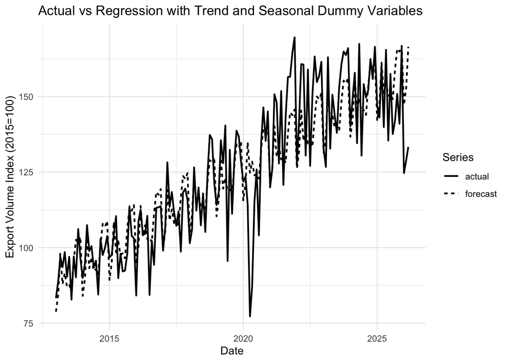

```r
plot_actual_vs_forecast(
  data = regression_data,
  forecast_column = "regression_seasonal_dummy_forecast",
  title = "Actual vs Regression with Trend and Seasonal Dummy Variables",
  file_name = "regression_seasonal_dummy_plot.png"
)
```

The regression model includes a time trend variable and monthly seasonal dummy variables. The trend coefficient shows the average monthly change in the export volume index after controlling for seasonal effects. The monthly dummy coefficients show how each month differs from the reference month.

# 21. Forecast Accuracy Comparison

The following table compares all candidate forecasting methods using the required accuracy and monitoring measures: Bias, MAD, MSE, MAPE, RSFE, Tracking Signal, and the next-period forecast.

```r
accuracy_comparison <- bind_rows(
  naive_accuracy,
  moving_average_accuracy,
  weighted_ma_accuracy,
  exponential_smoothing_accuracy,
  trend_adjusted_accuracy,
  linear_trend_accuracy,
  seasonal_indices_accuracy,
  additive_accuracy,
  multiplicative_accuracy,
  regression_accuracy
) %>%
  mutate(
    across(
      c(Bias, MAD, MSE, MAPE, RSFE, Tracking_Signal, Next_Period_Forecast),
      ~ round(.x, 3)
    )
  ) %>%
  arrange(MAPE)

accuracy_comparison %>%
  print(width = Inf)
```

```
## # A tibble: 10 × 8
##    Method                                       Bias   MAD   MSE  MAPE   RSFE
##    <chr>                                       <dbl> <dbl> <dbl> <dbl>  <dbl>
##  1 Multiplicative Decomposition               -0.012  8.39  132.  6.88  -1.96
##  2 Seasonal Indices                           -0.044  8.48  130.  7.00  -6.99
##  3 Additive Decomposition                      0      8.58  132.  7.09   0
##  4 Regression with Trend and Seasonal Dummies  0      8.59  131.  7.10   0
##  5 Trend-Adjusted Exponential Smoothing       -0.026 10.1   165.  8.31  -4.06
##  6 Linear Trend Projection                     0     10.3   176.  8.40   0
##  7 Exponential Smoothing                       1.46  10.4   167.  8.48 232.
##  8 Weighted Moving Average                     0.414 11.0   193.  9.02  64.6
##  9 Moving Average                              0.492 11.2   191.  9.21  76.8
## 10 Naïve Forecasting                           0.317 13.0   271. 10.7   50.0
##    Tracking_Signal Next_Period_Forecast
##              <dbl>                <dbl>
##  1          -0.234                 155.
##  2          -0.825                 153.
##  3           0                     155.
##  4           0                     156.
##  5          -0.4                   144.
##  6           0                     160.
##  7          22.2                   140.
##  8           5.85                  130.
##  9           6.83                  129.
## 10           3.84                  133.
```

```r
write.csv(
  accuracy_comparison,
  "outputs/tables/accuracy_comparison.csv",
  row.names = FALSE
)
```

The comparison table is sorted by MAPE. However, the final method selection is not based only on the lowest error value. The suitability of each method for the time series structure is also considered.

# 22. Superior Method Selection

The superior method is selected by considering both forecast accuracy and suitability for the structure of the selected time series.

```r
superior_method <- accuracy_comparison %>%
  slice_min(order_by = MAPE, n = 1)

superior_method
```

```
## # A tibble: 1 × 8
##   Method       Bias   MAD   MSE  MAPE  RSFE Tracking_Signal Next_Period_Forecast
##   <chr>       <dbl> <dbl> <dbl> <dbl> <dbl>           <dbl>                <dbl>
## 1 Multiplic… -0.012  8.39  132.  6.88 -1.96          -0.234                 155.
```

The selected superior method has the lowest MAPE among the candidate methods. In addition, the method is evaluated according to whether it can reasonably capture the observed structure of the monthly export volume index, including trend and seasonal movements.

# 23. Final Next-Period Forecast

The final forecast is produced for the next period after the latest available TÜİK observation.

```r
final_forecast <- tibble(
  Selected_Superior_Method = superior_method$Method,
  Data_Access_Date = Sys.Date(),
  Latest_Available_Observation = latest_available_observation,
  Forecast_Target_Period = forecast_target,
  Forecasted_Value = superior_method$Next_Period_Forecast,
  Bias = superior_method$Bias,
  MAD = superior_method$MAD,
  MSE = superior_method$MSE,
  MAPE = superior_method$MAPE,
  RSFE = superior_method$RSFE,
  Tracking_Signal = superior_method$Tracking_Signal
)

final_forecast %>%
  print(width = Inf)
```

```
## # A tibble: 1 × 11
##   Selected_Superior_Method     Data_Access_Date Latest_Available_Observation
##   <chr>                        <date>           <chr>
## 1 Multiplicative Decomposition 2026-05-29       2026-03
##   Forecast_Target_Period Forecasted_Value   Bias   MAD   MSE  MAPE  RSFE
##   <chr>                             <dbl>  <dbl> <dbl> <dbl> <dbl> <dbl>
## 1 2026-04                            155. -0.012  8.39  132.  6.88 -1.96
##   Tracking_Signal
##             <dbl>
## 1          -0.234
```

```r
write.csv(
  final_forecast,
  "outputs/tables/final_forecast.csv",
  row.names = FALSE
)
```

The selected model forecasts the Export Volume Index — General for the target period immediately following the latest available observation. Since the latest available observation is 2026-03, the forecast target period is 2026-04.

# 24. Superior Method Plot

The following plot shows the actual series together with the forecast values of the selected superior method.

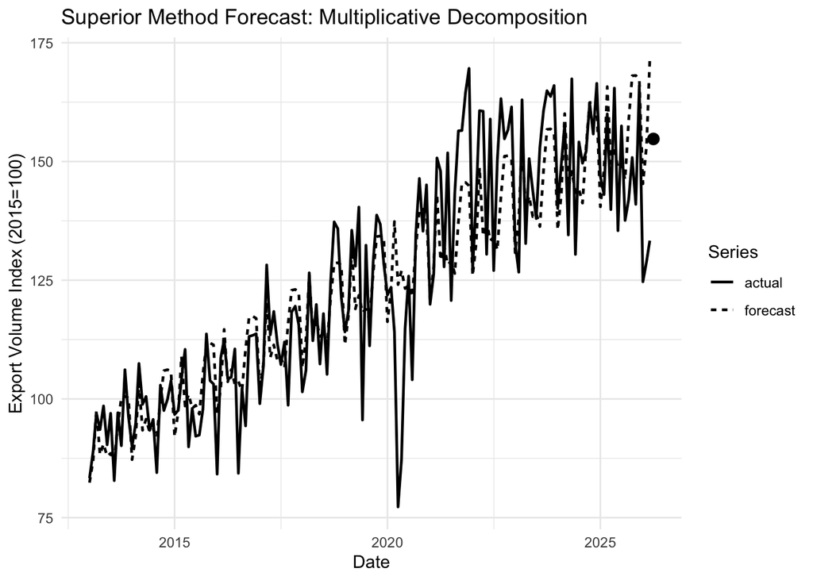

```r
superior_method_name <- superior_method$Method[1]

if (superior_method_name == "Naïve Forecasting") {
  superior_plot_data <- naive_data %>%
    select(date, actual = export_volume_index, forecast = naive_forecast)
} else if (superior_method_name == "Moving Average") {
  superior_plot_data <- moving_average_data %>%
    select(date, actual = export_volume_index, forecast = moving_average_forecast)
} else if (superior_method_name == "Weighted Moving Average") {
  superior_plot_data <- weighted_ma_data %>%
    select(date, actual = export_volume_index, forecast = weighted_moving_average_forecast)
} else if (superior_method_name == "Exponential Smoothing") {
  superior_plot_data <- exponential_smoothing_data %>%
    select(date, actual = export_volume_index, forecast = exponential_smoothing_forecast)
} else if (superior_method_name == "Trend-Adjusted Exponential Smoothing") {
  superior_plot_data <- trend_adjusted_data %>%
    select(date, actual = export_volume_index, forecast = trend_adjusted_forecast)
} else if (superior_method_name == "Linear Trend Projection") {
  superior_plot_data <- trend_data %>%
    select(date, actual = export_volume_index, forecast = linear_trend_forecast)
} else if (superior_method_name == "Seasonal Indices") {
  superior_plot_data <- seasonal_indices_forecast_data %>%
    select(date, actual = export_volume_index, forecast = seasonal_indices_forecast)
} else if (superior_method_name == "Additive Decomposition") {
  superior_plot_data <- additive_data %>%
    select(date, actual = export_volume_index, forecast = additive_decomposition_forecast)
} else if (superior_method_name == "Multiplicative Decomposition") {
  superior_plot_data <- multiplicative_data %>%
    select(date, actual = export_volume_index, forecast = multiplicative_decomposition_forecast)
} else if (superior_method_name == "Regression with Trend and Seasonal Dummies") {
  superior_plot_data <- regression_data %>%
    select(date, actual = export_volume_index, forecast = regression_seasonal_dummy_forecast)
}

superior_plot_long <- superior_plot_data %>%
  pivot_longer(
    cols = c(actual, forecast),
    names_to = "Series",
    values_to = "Value"
  )

superior_method_plot <- ggplot(superior_plot_long, aes(x = date, y = Value, linetype = Series)) +
  geom_line(linewidth = 0.8, na.rm = TRUE) +
  geom_point(
    data = tibble(
      date = forecast_target_period,
      Value = superior_method$Next_Period_Forecast,
      Series = "next_period_forecast"
    ),
    aes(x = date, y = Value),
    size = 3,
    inherit.aes = FALSE
  ) +
  labs(
    title = paste("Superior Method Forecast:", superior_method_name),
    x = "Date",
    y = "Export Volume Index (2015=100)",
    linetype = "Series"
  ) +
  theme_minimal()

superior_method_plot
```

```r
ggsave(
  filename = "outputs/figures/superior_method_plot.png",
  plot = superior_method_plot,
  width = 10,
  height = 6,
  dpi = 300
)
```

# 25. Limitations

This forecasting study has several limitations. First, the analysis uses only historical values of the export volume index and does not include external explanatory variables such as exchange rates, global demand, energy prices, geopolitical shocks, or trade policy changes. Second, the series may be affected by structural breaks and extraordinary economic events. Third, TÜİK data may be revised over time, which can affect future reproducibility. Finally, the selected methods are classical quantitative forecasting methods, so they may not fully capture complex nonlinear patterns.

# 26. Reproducibility Notes

The analysis is fully reproducible from the R Markdown notebook. The TÜİK table is identified through `tuikr::statistical_tables()`, and the data are retrieved programmatically in R using `httr::GET()`. No local manually downloaded data file is required.

The main output files generated by this notebook are:

- `outputs/tables/accuracy_comparison.csv`
- `outputs/tables/final_forecast.csv`
- `outputs/figures/actual_series_plot.png`
- Actual vs forecast plots for all candidate methods
- `outputs/figures/superior_method_plot.png`